# **Mock Project Using the Maximov (2021) Amphipod Dataset**

Muhammad Uzair Davids

2025-02-20

## **Setting up R**

```r
knitr::opts_chunk$set(echo = TRUE)
```

## **Loading packages for the analysis**

First, I load the packages I want to use to clean the data set.

```r
library(tidyverse) # The main package we will be using to tidy our data
```

```r
library(tidyr) # For the pivot longer function
library(dplyr) # To rename the columns
library(ggplot2) # To make the pretty graphs at the end
library(lubridate) # Will allow us to extract the year from date data later on
```

## **Loading the datasets**

The datasets used for this exercise is based on a dataset by [Alexy Maximov (2021)](https://doi.org/10.5061/dryad.0zpc866z6) titled: **Population dynamics of the glacial relict amphipod *Monoporeia affinis* in a subarctic lake**. This data set was used for the paper titled: Population dynamics of the glacial relict amphipods in a subarctic lake: role of density-dependent and density-independent factors.

There are three datasets: `data_environmental.csv` contains the data pertaining to the environmental variables, `data_macrzoobenthos.csv` contains data pertaining to the abundances of certain groups macrozoobenthos organisms, and `data_population.csv` contains the data pertaining to the age structure of the *Monoporeia* spp. population.

```r
# Load in environmental data
raw_env <- read.csv(
  "data/data_environmental.csv"
)

# Load in macrzoobenthos abundance data
raw_macro <- read.csv(
  "data/data_macrozoobenthos.csv"
)

# Load in population abundance data
raw_pop <- read.csv(
  "data/data_population.csv"
)
```

## **Inspect the data**

Now that we’ve loaded the data sets, lets have a closer look at the variables and some of the values they contain.

For a summary of the data sets we can use the `summary()` function.

```r
# summary of the environmental data set
summary(raw_env)
```

```
##       Year      Clorophyll.a..microgram.L.1      SE                T.mean
##  Min.   :2002   Min.   :0.8278              Length:18          Min.   :5.951
##  1st Qu.:2006   1st Qu.:1.1648              Class :character   1st Qu.:6.928
##  Median :2010   Median :1.3940              Mode  :character   Median :7.804
##  Mean   :2010   Mean   :1.3622                                 Mean   :8.004
##  3rd Qu.:2015   3rd Qu.:1.5444                                 3rd Qu.:8.942
##  Max.   :2019   Max.   :1.7692                                 Max.   :9.963
##      T.min           T.max
##  Min.   :3.000   Min.   : 6.700
##  1st Qu.:4.050   1st Qu.: 9.125
##  Median :4.600   Median :10.250
##  Mean   :4.483   Mean   :10.633
##  3rd Qu.:5.000   3rd Qu.:13.075
##  Max.   :6.200   Max.   :13.700
```

```r
# summary of the macrozoobenthos data set
summary(raw_macro)
```

```
##       Year      Monoporeia..ind.m.2 Chironomidae..ind.m.2 Others..ind.m.2
##  Min.   :2002   Min.   :140.0       Min.   : 236.0        Min.   : 27.00
##  1st Qu.:2006   1st Qu.:239.0       1st Qu.: 614.8        1st Qu.: 52.25
##  Median :2010   Median :413.0       Median : 795.5        Median : 80.50
##  Mean   :2010   Mean   :400.4       Mean   : 802.3        Mean   : 74.06
##  3rd Qu.:2015   3rd Qu.:512.0       3rd Qu.: 964.0        3rd Qu.: 91.00
##  Max.   :2019   Max.   :799.0       Max.   :1250.0        Max.   :113.00
##  Macrozoobenthos..ind.m.2
##  Min.   : 499.0
##  1st Qu.: 902.8
##  Median :1300.5
##  Mean   :1276.7
##  3rd Qu.:1592.2
##  Max.   :1884.0
```

```r
# summary of the population data set
summary(raw_pop)
```

```
##      Date           N.0...ind.m.2   N.1...ind.m.2   N.2...ind.m.2
##  Length:80          Min.   : 32.0   Min.   : 24.0   Min.   : 0.000
##  Class :character   1st Qu.:134.5   1st Qu.: 96.0   1st Qu.: 0.000
##  Mode  :character   Median :208.0   Median :160.0   Median : 0.000
##                     Mean   :237.9   Mean   :165.5   Mean   : 5.388
##                     3rd Qu.:314.0   3rd Qu.:221.0   3rd Qu.: 0.000
##                     Max.   :827.0   Max.   :368.0   Max.   :96.000
##  N.population..ind.m.2       SE
##  Min.   :  56.0        Min.   : 16.00
##  1st Qu.: 249.8        1st Qu.: 37.75
##  Median : 375.0        Median : 60.00
##  Mean   : 408.8        Mean   : 68.76
##  3rd Qu.: 538.0        3rd Qu.: 87.25
##  Max.   :1187.0        Max.   :308.00
```

We can also use the `head()` and `tail()` functions. `head()` will allow us to view the first few rows of the data, whereas `tail()` will allow us to view the last few rows.

```r
# first few rows of the environmental data
head(raw_env)
```

```
##   Year Clorophyll.a..microgram.L.1      SE   T.mean T.min T.max
## 1 2002                    1.216229 No data 5.950667   4.8   6.7
## 2 2003                    1.717744 No data 6.840196   3.2   8.8
## 3 2004                    1.473416 No data 7.750439   5.6   9.2
## 4 2005                    1.203369 No data 6.960526   5.0   8.3
## 5 2006                    1.151932 No data 7.857143   4.2  12.4
## 6 2007                    1.036197 No data 9.554960   6.2  11.5
```

```r
# last few rows of the environmental data
tail(raw_env)
```

```
##    Year Clorophyll.a..microgram.L.1          SE   T.mean T.min T.max
## 13 2014                    1.475911 0.434446199 6.916768   3.0   9.2
## 14 2015                    1.314911 0.322055896 8.925305   4.7  13.7
## 15 2016                    1.544911 0.285029238 9.744545   5.1  13.3
## 16 2017                    1.542768  0.20902511 6.113265   4.0   9.1
## 17 2018                    1.469931 0.181463443 9.963437   5.0  13.7
## 18 2019                    1.609142 0.355724958 7.450000   3.3   9.5
```

```r
# first few rows of the macrozoobenthos data
head(raw_macro)
```

```
##   Year Monoporeia..ind.m.2 Chironomidae..ind.m.2 Others..ind.m.2
## 1 2002                 245                   573              56
## 2 2003                 516                   972              81
## 3 2004                 799                   940              77
## 4 2005                 714                   802              39
## 5 2006                 223                   236              40
## 6 2007                 212                   478              51
##   Macrozoobenthos..ind.m.2
## 1                      875
## 2                     1569
## 3                     1815
## 4                     1556
## 5                      499
## 6                      741
```

```r
# last few rows of the macrozoobenthos data
tail(raw_macro)
```

```
##    Year Monoporeia..ind.m.2 Chironomidae..ind.m.2 Others..ind.m.2
## 13 2014                 482                  1144              92
## 14 2015                 546                  1250              88
## 15 2016                 514                   912             107
## 16 2017                 360                   860             113
## 17 2018                 466                   698             106
## 18 2019                 506                  1245             103
##    Macrozoobenthos..ind.m.2
## 13                     1718
## 14                     1884
## 15                     1533
## 16                     1332
## 17                     1269
## 18                     1854
```

```r
# first few rows of the population data
head(raw_pop)
```

```
##         Date N.0...ind.m.2 N.1...ind.m.2 N.2...ind.m.2 N.population..ind.m.2
## 1 2002/06/10           120           107             0                   227
## 2 2002/06/25            80           133             0                   213
## 3 2002/08/01           187           187             0                   374
## 4 2002/08/19           173            80             0                   253
## 5 2002/09/14           100            60             0                   160
## 6 2003/03/30           160           160            20                   340
##    SE
## 1  35
## 2  35
## 3  35
## 4  67
## 5  40
## 6 137
```

```r
# last few rows of the population data
tail(raw_pop)
```

```
##          Date N.0...ind.m.2 N.1...ind.m.2 N.2...ind.m.2 N.population..ind.m.2
## 75 2019/06/15           280           256             8                   544
## 76 2019/07/21           184           192             8                   384
## 77 2019/08/25           368           256             0                   624
## 78 2019/09/08           288           224             0                   512
## 79 2019/10/28           240           216             0                   456
## 80 2019/12/30           336           168             0                   504
##     SE
## 75 122
## 76  60
## 77 164
## 78  37
## 79  89
## 80  64
```

# **Tidying the data**

The first step of this exercise will be to ensure that the data we’re using is in *tidy format*. Ensuring that our data is in *tidy format* helps to make the workflow easier to follow, but also allows for more effective communication and reproductibility of research.

There are also other steps we can take to tidy the data further, such as renaming columns, which may help with the reproducible aspect of this assignment.

## **Removing missing and invalid data**

Gaps in data sets are considered to be in violation of *tidy format*. The environmental data set contains cells with “No data” values - which we saw after using the `head()` function above. To fix this, we will replace the “No data” message with `NA`.

```r
raw_env[raw_env == "No data"] <- NA # Replace "No data" with NA
```

## **Removing redundant data**

Currently the macrozoobenthos and population datasets contain data which could be considered as redundant - the “Mean annual abundance of all macrozoobenthos (individuals.m-2)” column is just the sum of mean annual abundance of all the organisms, and the “Total population abundance (individuals.m-2)” column is the sum of all age groups in the population - so we will remove them to make plotting the data easier.

```r
# remove redundant columns from the macrozoobenthos dataset
raw_macro <- raw_macro %>% select(-`Macrozoobenthos..ind.m.2`)

# remove redundant columns from the population dataset
raw_pop <- raw_pop %>% select(-`N.population..ind.m.2`)
```

## **Rename columns**

Some of the column names in the data set are not easily understood, so I will change them to make them easier to understand.

```r
# Rename the environmental data columns
tidy_env <- raw_env %>% rename(
  "Mean Concentration of Chlorophyll-a (µg.L-1)"
  = Clorophyll.a..microgram.L.1,
  "Standard Error (µg.L-1)"
  = SE,
  "Mean Near-Bottom Temperature (°C)"
  = T.mean,
  "Minimum Near-Bottom Temperature (°C)"
  = T.min,
  "Maximum Near-Bottom Temperature (°C)"
  = T.max
)

# Rename the macrozoobenthos abundance data columns
tidy_macro <- raw_macro %>% rename(
  "Mean annual abundance of Monoporeia affinis (individuals.m-2)"
  = Monoporeia..ind.m.2,
  "Mean annual abundance of chironomids (individuals.m-2)"
  = Chironomidae..ind.m.2,
  "Mean annual abundance of other taxa (individuals.m-2)"
  = Others..ind.m.2
)

# Rename the population abundance data columns
tidy_pop <- raw_pop %>% rename(
  "Abundance of age group 0+ (individuals.m-2)"
  = N.0...ind.m.2,
  "Abundance of age group 1+ (individuals.m-2)"
  = N.1...ind.m.2,
  "Abundance of age group 2+ (individuals.m-2)"
  = N.2...ind.m.2,
  "Standard error (individuals.m-2)"
  = SE
)
```

## **Pivot longer**

Currently, our data is in *wide format*, which violates the tidy format guidelines. So let’s fix that using the `pivot_longer` function from the `tidyr` package. This will allow us to convert the data into *long format*.

```r
# convert the environmental data to long format
long_env <- tidy_env %>%
  pivot_longer(
    cols = c(
      "Mean Near-Bottom Temperature (°C)",
      "Minimum Near-Bottom Temperature (°C)",
      "Maximum Near-Bottom Temperature (°C)"
    ),
    # Select the columns to pivot
    names_to = "Variable",
    # New column name for previous column headers
    values_to = "Value"
  )      # New column for data values

# convert the macrozoobenthos data to long format
long_macro <- tidy_macro %>%
  pivot_longer(
    cols = c(
      "Mean annual abundance of Monoporeia affinis (individuals.m-2)",
      "Mean annual abundance of chironomids (individuals.m-2)",
      "Mean annual abundance of other taxa (individuals.m-2)"
    ),
    # Select the columns to pivot
    names_to = "Variable",
    # New column name for previous column headers
    values_to = "Value"
  )      # New column for data values

# convert the population data to long format
long_pop <- tidy_pop %>%
  pivot_longer(
    cols = c(
      "Abundance of age group 0+ (individuals.m-2)",
      "Abundance of age group 1+ (individuals.m-2)",
      "Abundance of age group 2+ (individuals.m-2)"
    ),
    # Select the columns to pivot
    names_to = "Variable",
    # New column name for previous column headers
    values_to = "Value"
  )      # New column for data values
```

## **Plot the tidied data**

Now that we’ve converted the data to *long format*, we can consider our data to be in tidy format - so let’s plot it!

I’ll just plot the population structure as an exmaple.

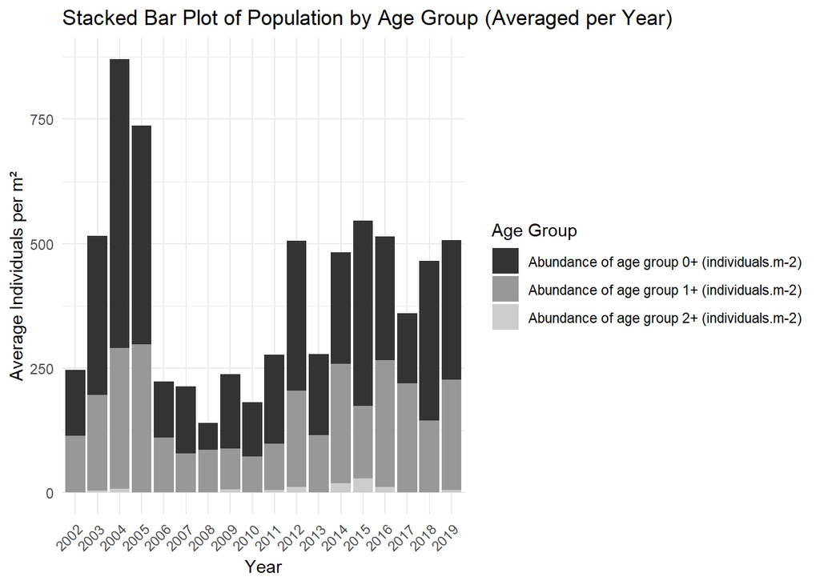

```r
# Convert Date column to Date format (if not already)
long_pop <- long_pop %>%
  mutate(Year = year(Date))  # Extract year from the Date column

# Summarizing data: Average number of individuals per age group per year
pop_summary <- long_pop %>%
  group_by(Year, Variable) %>%  # Group by Year and Age Group
  summarise(Avg_Individuals = mean(Value), .groups = 'drop')  # Average per year

# Create the stacked bar plot
ggplot(pop_summary,
       aes(x = as.factor(Year), y = Avg_Individuals, fill = Variable)) +
  geom_col(position = "stack") +  # Stacked bars
  scale_fill_grey(start = 0.2, end = 0.8) +  # Monochrome gradient
  theme_minimal() +
  labs(title = "Stacked Bar Plot of Population by Age Group (Averaged per Year)",
       x = "Year",
       y = "Average Individuals per m²",
       fill = "Age Group") +
  theme(axis.text.x = element_text(angle = 45, hjust = 1))  # Rotate date labels
```